# MBOA and BOA metabolization LSP13 bxdA mutants

Thoenen et al. AMPO formation

Lisa Thönen & Christine Pestalozzi

2024-05-14

# Set settings

set working directory to source file location

# Packages

Library loading, setting up misc functionsl

# TSB

## Data

Load data -metadata: Information on the samples for metabolite analysis. There were additional samples run in the same run that are not relevant to this paper. Metadata for these is therefore omitted. -data_MBOA: “Compound 8: MBOA” -> table starts at Row 3 (-Row49) -data_AMPO: “Compound 16: AMPO” -> table starts at Row 53 (-Row99)

Format the data

Calculations concentrations

Quantification & calculations: using a standard curve the samples are quantified

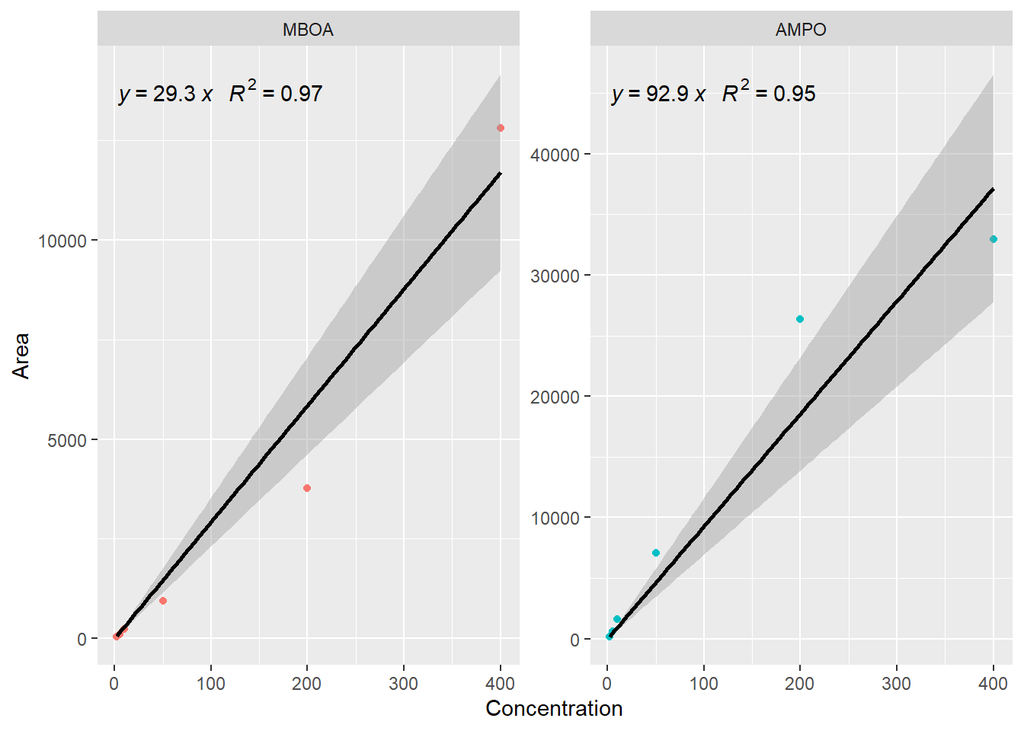

## Plot

Fig 5c: Metabolization of MBOA in 0.5xTSB supplemented with 500 uM MBOA. Plot MBOA and AMPO combined, then plot only AMPO separately for better visualization

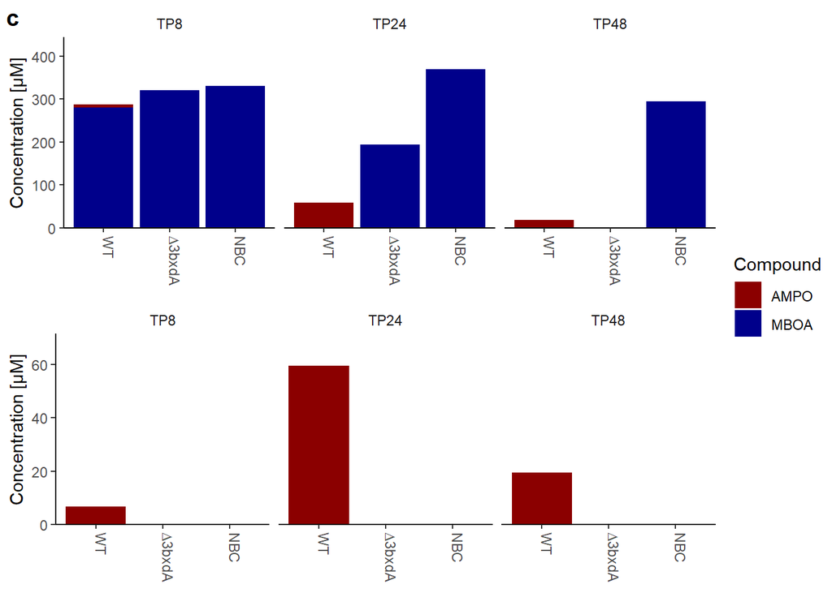

# Minimal medium

## Data

Calculations concentrations

Quantification & calculations: using a standard curve the samples are quantified

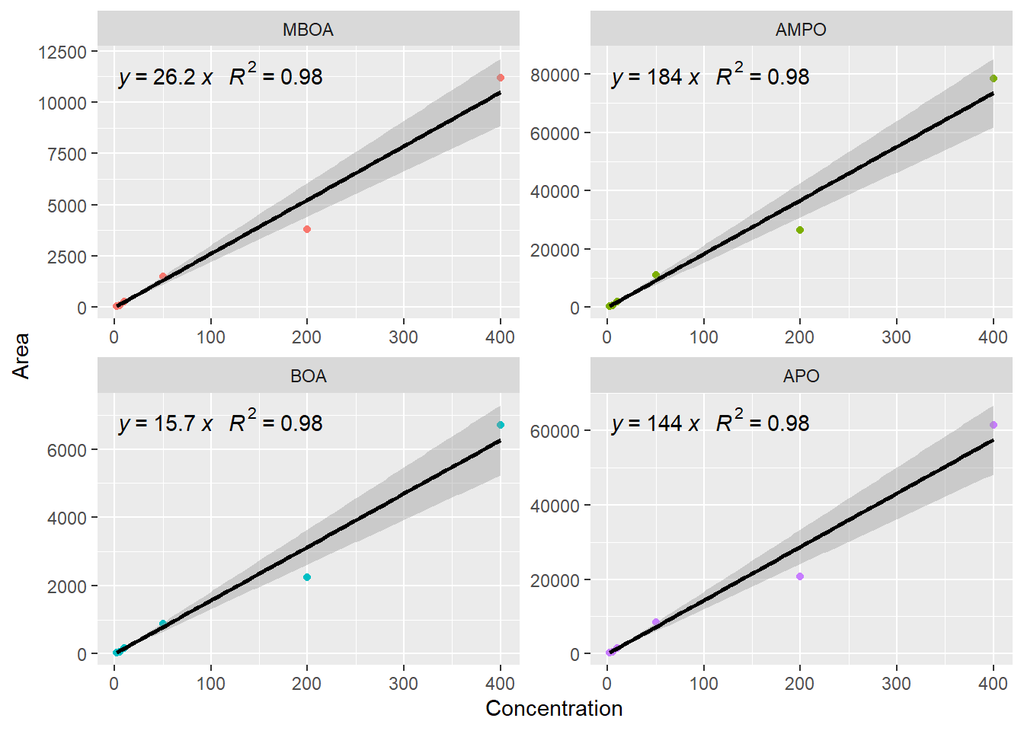

## Plot MM

### MBOA plots

Fig 5d: Metabolization of MBOA in minimal medium supplemented with 500 uM MBOA. Prepare first separate plots for MBOA and AMPO together and for AMPO only. Combine afterwards

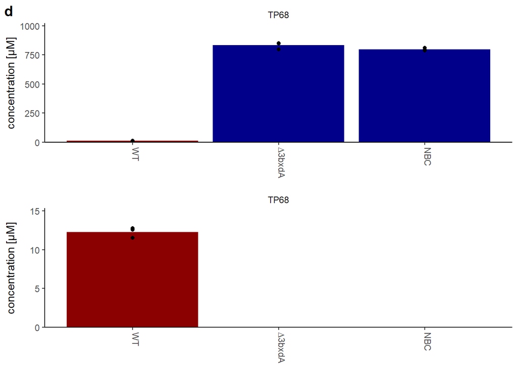

#### BOA plots

Fig S11d: Metabolization of BOA in minimal medium supplemented with 500 uM BOA. Shown are BOA and APO side by side

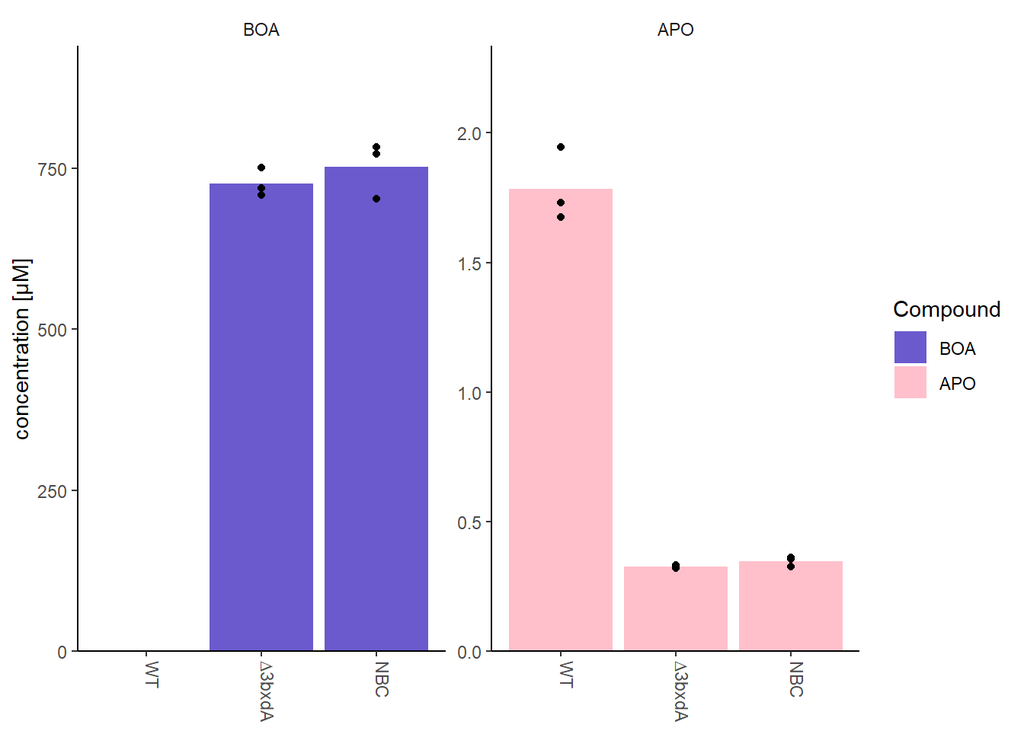